# DATA 605 Week 12 Homework

Yohannes Deboch

04/18/2019

### Background Information about the Task

This home work is based on real-world Health Organization data from 208. Based on the data set I will be answering the required questions.

### Data Import

```r
# Import data
who <- read.csv('https://raw.githubusercontent.com/jonygeta/Data605-Week-12-Homework-/master/who.csv')

knitr::kable(head(who[,c(1,2,6,8,9,10)]))
```

| Country | LifeExp | PropMD | PersExp | GovtExp | TotExp |
| --- | --- | --- | --- | --- | --- |
| Afghanistan | 42 | 0.0002288 | 20 | 92 | 112 |
| Albania | 71 | 0.0011431 | 169 | 3128 | 3297 |
| Algeria | 71 | 0.0010605 | 108 | 5184 | 5292 |
| Andorra | 82 | 0.0032973 | 2589 | 169725 | 172314 |
| Angola | 41 | 0.0000704 | 36 | 1620 | 1656 |
| Antigua and Barbuda | 73 | 0.0001429 | 503 | 12543 | 13046 |

Data is real-world World Health Organization data from 2008. It includes 190 observations for 10 variables. Data dictionary:

- `Country`: name of the country
- `LifeExp`: average life expectancy for the country in years
- `InfantSurvival`: proportion of those surviving to one year or more
- `Under5Survival`: proportion of those surviving to five years or more
- `TBFree`: proportion of the population without TB
- `PropMD`: proportion of the population who are MDs
- `PropRN`: proportion of the population who are RNs
- `PersExp`: mean personal expenditures on healthcare in US dollars at average exchange rate
- `GovtExp`: mean government expenditures per capita on healthcare, US dollars at average exchange rate
- `TotExp`: sum of personal and government expenditures

### Data Exploration

```r
summary(who)
```

```
##                 Country       LifeExp      InfantSurvival
##  Afghanistan        :  1   Min.   :40.00   Min.   :0.8350
##  Albania            :  1   1st Qu.:61.25   1st Qu.:0.9433
##  Algeria            :  1   Median :70.00   Median :0.9785
##  Andorra            :  1   Mean   :67.38   Mean   :0.9624
##  Angola             :  1   3rd Qu.:75.00   3rd Qu.:0.9910
##  Antigua and Barbuda:  1   Max.   :83.00   Max.   :0.9980
##  (Other)            :184
##  Under5Survival       TBFree           PropMD              PropRN
##  Min.   :0.7310   Min.   :0.9870   Min.   :0.0000196   Min.   :0.0000883
##  1st Qu.:0.9253   1st Qu.:0.9969   1st Qu.:0.0002444   1st Qu.:0.0008455
##  Median :0.9745   Median :0.9992   Median :0.0010474   Median :0.0027584
##  Mean   :0.9459   Mean   :0.9980   Mean   :0.0017954   Mean   :0.0041336
##  3rd Qu.:0.9900   3rd Qu.:0.9998   3rd Qu.:0.0024584   3rd Qu.:0.0057164
##  Max.   :0.9970   Max.   :1.0000   Max.   :0.0351290   Max.   :0.0708387
##
##     PersExp           GovtExp             TotExp
##  Min.   :   3.00   Min.   :    10.0   Min.   :    13
##  1st Qu.:  36.25   1st Qu.:   559.5   1st Qu.:   584
##  Median : 199.50   Median :  5385.0   Median :  5541
##  Mean   : 742.00   Mean   : 40953.5   Mean   : 41696
##  3rd Qu.: 515.25   3rd Qu.: 25680.2   3rd Qu.: 26331
##  Max.   :6350.00   Max.   :476420.0   Max.   :482750
##
```

Based the observed lowest and highest expenditures (13 to 482,750), I am interested to see top and bottom countries.

Bottom 5 Countries by Total Expenditures

| Country | LifeExp | PropMD | PersExp | GovtExp | TotExp |
| --- | --- | --- | --- | --- | --- |
| Burundi | 49 | 0.0000245 | 3 | 10 | 13 |
| Ethiopia | 56 | 0.0000239 | 6 | 64 | 70 |
| Democratic Republic of the Congo | 47 | 0.0000961 | 5 | 66 | 71 |
| Nepal | 62 | 0.0001948 | 16 | 64 | 80 |
| Bangladesh | 63 | 0.0002749 | 12 | 75 | 87 |

Top 5 Countries by Total Expenditures

| Country | LifeExp | PropMD | PersExp | GovtExp | TotExp |
| --- | --- | --- | --- | --- | --- |
| Denmark | 79 | 0.0035519 | 4350 | 314588 | 318938 |
| Norway | 80 | 0.0037531 | 5910 | 380380 | 386290 |
| Iceland | 81 | 0.0037584 | 5154 | 395622 | 400776 |
| Monaco | 82 | 0.0056364 | 6128 | 458700 | 464828 |
| Luxembourg | 80 | 0.0027223 | 6330 | 476420 | 482750 |

### Question 1

Provide a scatterplot of LifeExp~TotExp, and run simple linear regression. Do not transform the variables. Provide and interpret the F statistics, R^2, standard error,and p-values only. Discuss whether the assumptions of simple linear regression met.

To answer this question building a linear regression model for predicting life expectancy by total expenditures is important. The provided scatterplot shows the relationship along with the linear regression line.

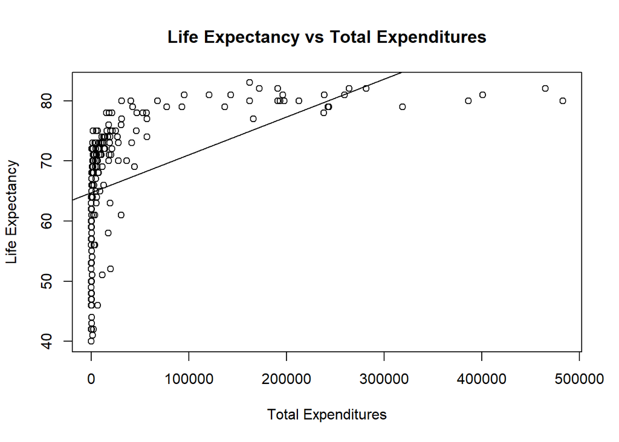

```r
# Linear regression model build
life_exp_lm <- lm(LifeExp ~ TotExp, data=who)

# Scatterplot of dependent and independent variables
plot(LifeExp~TotExp, data=who,
     xlab="Total Expenditures", ylab="Life Expectancy",
     main="Life Expectancy vs Total Expenditures")
abline(life_exp_lm)
```

```r
# Linear regression model summary
summary(life_exp_lm)
```

```
##
## Call:
## lm(formula = LifeExp ~ TotExp, data = who)
##
## Residuals:
##     Min      1Q  Median      3Q     Max
## -24.764  -4.778   3.154   7.116  13.292
##
## Coefficients:
##                 Estimate   Std. Error t value           Pr(>|t|)
## (Intercept) 64.753374534  0.753536611  85.933            < 2e-16 ***
## TotExp       0.000062970  0.000007795   8.079 0.0000000000000771 ***
## ---
## Signif. codes:  0 '***' 0.001 '**' 0.01 '*' 0.05 '.' 0.1 ' ' 1
##
## Residual standard error: 9.371 on 188 degrees of freedom
## Multiple R-squared:  0.2577, Adjusted R-squared:  0.2537
## F-statistic: 65.26 on 1 and 188 DF,  p-value: 0.00000000000007714
```

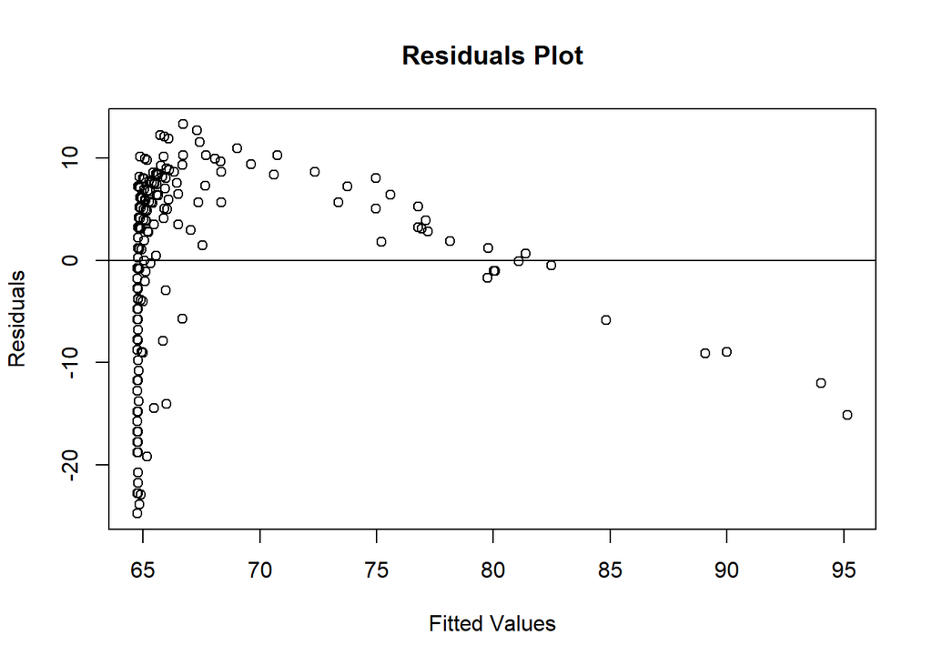

```r
# Residuals variability plot
plot(life_exp_lm$fitted.values, life_exp_lm$residuals,
     xlab="Fitted Values", ylab="Residuals",
     main="Residuals Plot")
abline(h=0)
```

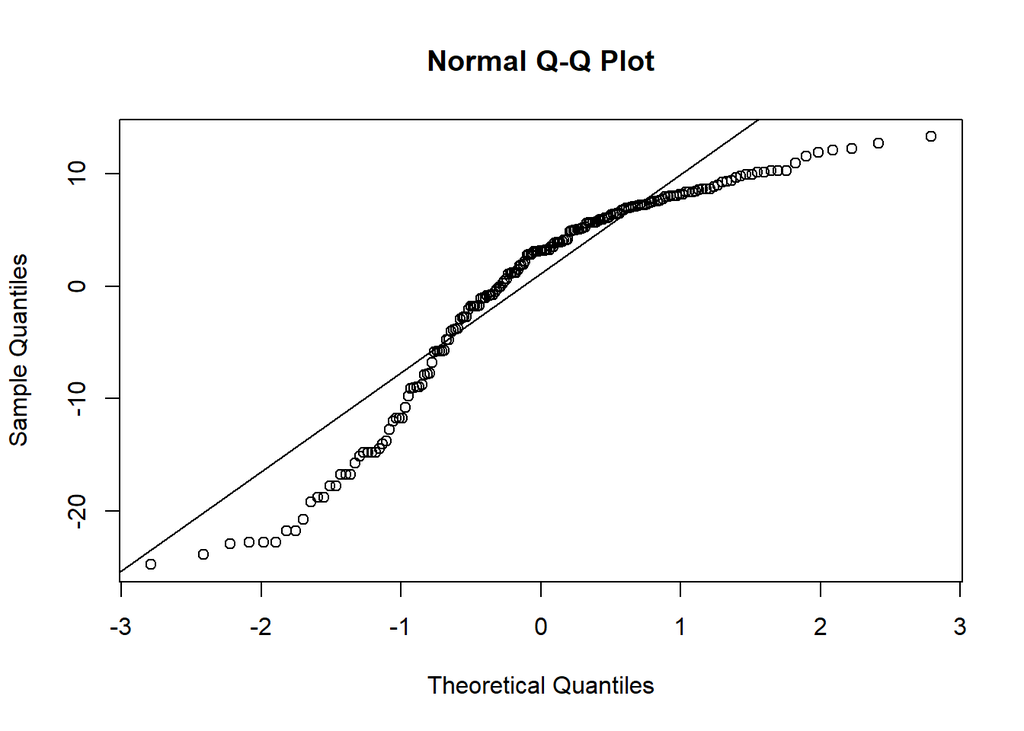

```r
# Residuals Q-Q plot
qqnorm(life_exp_lm$residuals)
qqline(life_exp_lm$residuals)
```

#### Observed Results

**Residual standard error** is 9.371 and **F-statistic** is 65.26. Taking in to account the average life expectancy of 67.38, the SE is not terrible and F-statistics is high. However, $R^2$ is only 0.2577 (so the model explains only 25.77% of variability). **P-value** is nearly 0, so the relationship is not due to random variation.

As per the residuals plots there is no constant variability and that residuals are not normally distributed. This is **not a good model** to describe the relationship. The scatterplot shows that the relationship is not linear.

### Question 2

Raise life expectancy to the 4.6 power (i.e., LifeExp^4.6). Raise total expenditures to the 0.06 power (nearly a log transform, TotExp^.06). Plot LifeExp^4.6 as a function of TotExp^.06, and r re-run the simple regression model using the transformed variables. Provide and interpret the F statistics, R^2, standard error, and p-values. Which model is “better?”

To answer I will be trasnforming the variables and re-run the simple linear regression model - $LifeExp^{4.6}$ and $TotExp^{0.06}$.

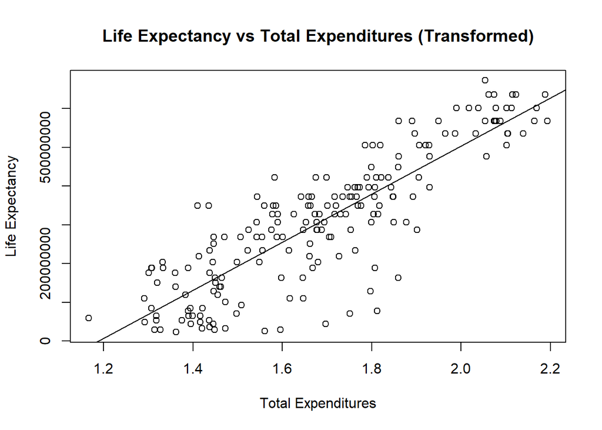

```r
# Transformation
LifeExp4.6 <- who$LifeExp^4.6
TotExp0.06 <- who$TotExp^0.06

# Linear regression model build
life_exp_lm <- lm(LifeExp4.6 ~ TotExp0.06)

# Scatterplot of dependent and independent variables
plot(LifeExp4.6~TotExp0.06,
     xlab="Total Expenditures", ylab="Life Expectancy",
     main="Life Expectancy vs Total Expenditures (Transformed)")
abline(life_exp_lm)
```

```r
# Linear regression model summary
summary(life_exp_lm)
```

```
##
## Call:
## lm(formula = LifeExp4.6 ~ TotExp0.06)
##
## Residuals:
##        Min         1Q     Median         3Q        Max
## -308616089  -53978977   13697187   59139231  211951764
##
## Coefficients:
##               Estimate Std. Error t value Pr(>|t|)
## (Intercept) -736527910   46817945  -15.73   <2e-16 ***
## TotExp0.06   620060216   27518940   22.53   <2e-16 ***
## ---
## Signif. codes:  0 '***' 0.001 '**' 0.01 '*' 0.05 '.' 0.1 ' ' 1
##
## Residual standard error: 90490000 on 188 degrees of freedom
## Multiple R-squared:  0.7298, Adjusted R-squared:  0.7283
## F-statistic: 507.7 on 1 and 188 DF,  p-value: < 2.2e-16
```

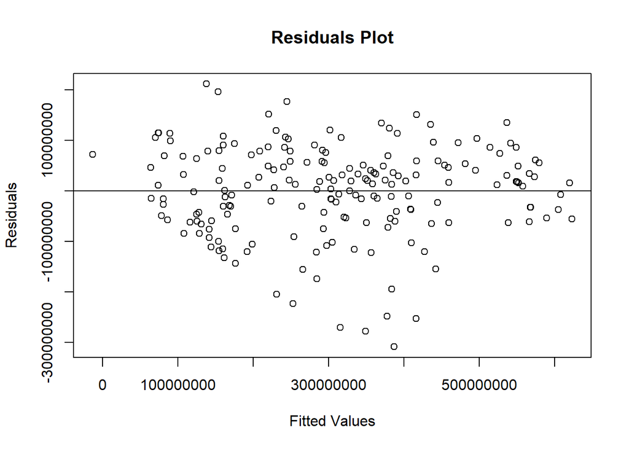

```r
# Residuals variability plot
plot(life_exp_lm$fitted.values, life_exp_lm$residuals,
     xlab="Fitted Values", ylab="Residuals",
     main="Residuals Plot")
abline(h=0)
```

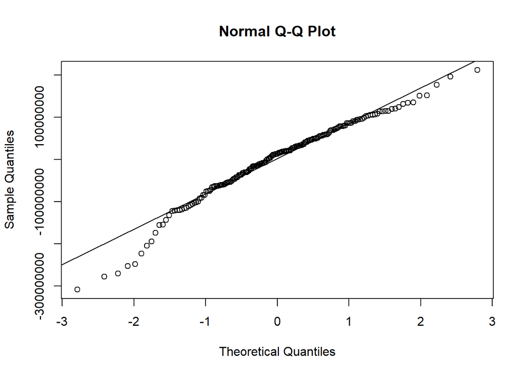

```r
# Residuals Q-Q plot
qqnorm(life_exp_lm$residuals)
qqline(life_exp_lm$residuals)
```

#### Observed Results

**Residual standard error** is 90,490,000 and **F-statistic** is 507.7. The F-statistic is good, but the SE is a bit high considering that it corresponds to 53.67 years if we reverse the transformation). $R^2$ is 0.7298, which is considerably better than in the first model (the model explains 72.98% of variability). **P-value** is again nearly 0, so the relationship is not due to random variation.

As it can be observed from residuals plots, variability is fairly constant with a few outliers and distribution of residuals is nearly normal with some deviation at the tails. This is **a fairly good model** to describe the relationship and it is significantly better than the first model. The linear relationship between transformed variables is clear from the scatterplot.

### Question 3

Using the results from 3, forecast life expectancy when TotExp^.06 =1.5. Then forecast life expectancy when TotExp^.06=2.5.

```r
newdata <- data.frame(TotExp0.06=c(1.5,2.5))
predict(life_exp_lm, newdata,interval="predict")^(1/4.6)
```

```
##        fit      lwr      upr
## 1 63.31153 35.93545 73.00793
## 2 86.50645 81.80643 90.43414
```

As per the observation from the second model, prediction for total expeditures of $860.705 ($TotExp^{0.06}=1.5$) is 63.31 years with a 95% confidence interval between 35.94 and 73.01.

Prediction for total expeditures of $4,288,777 ($TotExp^{0.06}=2.5$) is 86.51 years with a 95% confidence interval between 81.81 and 90.43.

### Question 4

Build the following multiple regression model and interpret the F Statistics, R^2, standard error, and p-values. How good is the model? LifeExp = b0+b1 x PropMd + b2 x TotExp +b3 x PropMD x TotExp

Let us build the following model: $LifeExp = \beta_0+\beta_1 \times PropMD + \beta_2 \times TotExp + \beta_3 \times PropMD \times TotExp$.

```r
# Multiple linear regression model build
life_exp_lm <- lm(LifeExp ~ PropMD + TotExp + TotExp:PropMD, data=who)

# Linear regression model summary
summary(life_exp_lm)
```

```
##
## Call:
## lm(formula = LifeExp ~ PropMD + TotExp + TotExp:PropMD, data = who)
##
## Residuals:
##     Min      1Q  Median      3Q     Max
## -27.320  -4.132   2.098   6.540  13.074
##
## Coefficients:
##                     Estimate     Std. Error t value           Pr(>|t|)
## (Intercept)     62.772703255    0.795605238  78.899            < 2e-16 ***
## PropMD        1497.493952519  278.816879652   5.371 0.0000002320602774 ***
## TotExp           0.000072333    0.000008982   8.053 0.0000000000000939 ***
## PropMD:TotExp   -0.006025686    0.001472357  -4.093 0.0000635273294941 ***
## ---
## Signif. codes:  0 '***' 0.001 '**' 0.01 '*' 0.05 '.' 0.1 ' ' 1
##
## Residual standard error: 8.765 on 186 degrees of freedom
## Multiple R-squared:  0.3574, Adjusted R-squared:  0.3471
## F-statistic: 34.49 on 3 and 186 DF,  p-value: < 2.2e-16
```

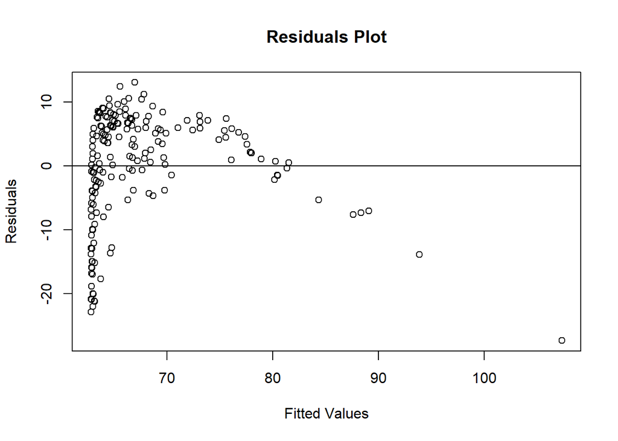

```r
# Residuals variability plot
plot(life_exp_lm$fitted.values, life_exp_lm$residuals,
     xlab="Fitted Values", ylab="Residuals",
     main="Residuals Plot")
abline(h=0)
```

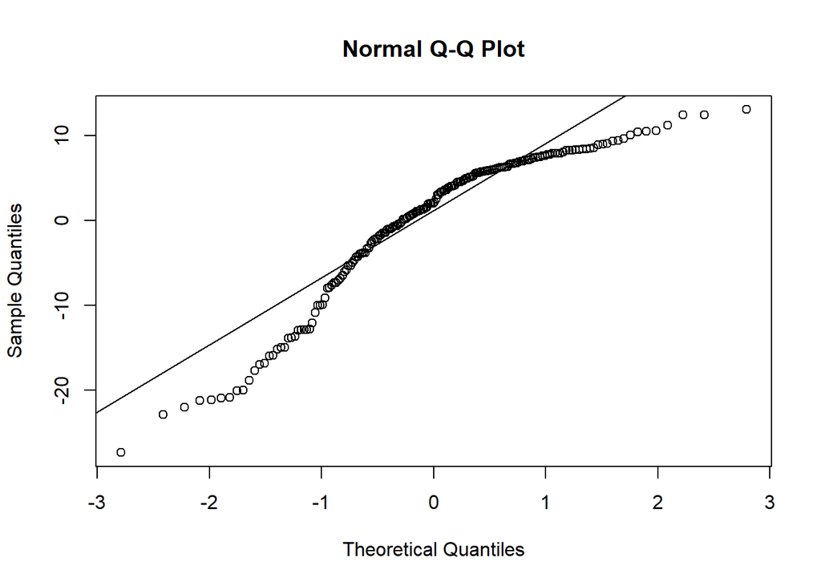

```r
# Residuals Q-Q plot
qqnorm(life_exp_lm$residuals)
qqline(life_exp_lm$residuals)
```

#### Observed Results

**Residual standard error** is 8.765 and **F-statistic** is 34.49. Considering that average life expectancy is 67.38, the SE is not terrible and F-statistics is fairly high (but lower than in the first model). $R^2$ is only 0.3574, so the model explains only 35.74% of variability, which is not high. **P-value** is nearly 0, so the relationship is not due to random variation.

As per the residuals plots it is clear that there is no constant variability and that residuals are not normally distributed. Therefore, This is **not a good model** to describe the relationship similar to the first model in question 1.

### Question 5

Forecast LifeExp when PropMD=.03 and TotExp = 14. Does this forecast seem realistic? Why or why not?

To answer I will be considering forecast based on the last model with $PropMD = 0.03$ and $TotExp = 14$.

```r
newdata <- data.frame(PropMD=0.03, TotExp=14)
predict(life_exp_lm, newdata,interval="predict")
```

```
##       fit      lwr      upr
## 1 107.696 84.24791 131.1441
```

The prediction is 107.70 years with 95% confidence interval between 84.25 and 131.14. As per our observation the prediction i unrealistic and not dependable . We can observe e individuals livings into their 100s; however, consider that the total expenditures of $14 is just a tad higher than the minimum value of $13 for Burundi where the life expectancy 49 years. We do not have data to support prediction of 107.70 years where as the data that we have shows the highest life expectancy of 83 years . Due to this we can conclude that the forcast is unrealistic.